# EDA on Vegas Strip Hotel scores

Arun Marria, Bronwyn Baillie, Manish Joshi 2020-01-17 (updated: 2020-02-08)

## Contents

1. Introduction
2. Cleaning and wrangling data
3. Exploring relationship between features and hotel scores
   - Inspecting relationship between hotel scores and categorical features
   - Inspecting relationship between hotel scores and numeric features
4. Summary of EDA
5. Next Steps

## Introduction

In this document we perform exploratory data analysis on `Vegas Strip` dataaset to see if there is any relationship between different amenities which hotels provide and the score which guests give to those hotels on the strip. This exploratory analysis will then be extended to see if a predictive regression model can be developed to estimate user ratings based on hotel amenities.

Loading required libraries

```r
# loading required libraries
library(tidyverse)
library(caret)
library(readr)
library(ggplot2)
library(GGally)
library(repr)
library(gridExtra)
```

Before doing any EDA splitting dataset into training and test set.

```r
# reading dataset
vegas_data <- read_csv2("../data/raw/vegas_data.csv")
```

```
## Using ',' as decimal and '.' as grouping mark. Use read_delim() for more control.
```

```r
#splitting into training test data set  based on hotel names
set.seed(787)
train_index <- caret::createDataPartition(vegas_data$`Hotel name`,  p = 0.75, list = FALSE)
training_set <- vegas_data[train_index,]
test_set <- vegas_data[- train_index,]

dim(training_set)
```

```
## [1] 378  20
```

```r
dim(test_set)
```

```
## [1] 126  20
```

## Cleaning and wrangling data

Checking top rows and column names of the dataset.

```r
head(training_set)
```

```
## # A tibble: 6 x 20
##   `User country` `Nr. reviews` `Nr. hotel revi… `Helpful votes` Score
##   <chr>                  <dbl>            <dbl>           <dbl> <dbl>
## 1 USA                       11                4              13     5
## 2 USA                       36                9              25     5
## 3 Canada                    31                8              27     3
## 4 UK                        45               12              46     4
## 5 USA                        2                1               4     4
## 6 India                     24                3               8     4
## # … with 15 more variables: `Period of stay` <chr>, `Traveler type` <chr>,
## #   Pool <chr>, Gym <chr>, `Tennis court` <chr>, Spa <chr>, Casino <chr>,
## #   `Free internet` <chr>, `Hotel name` <chr>, `Hotel stars` <dbl>, `Nr.
## #   rooms` <dbl>, `User continent` <chr>, `Member years` <dbl>, `Review
## #   month` <chr>, `Review weekday` <chr>
```

```r
colnames(training_set)
```

```
##  [1] "User country"      "Nr. reviews"       "Nr. hotel reviews"
##  [4] "Helpful votes"     "Score"             "Period of stay"
##  [7] "Traveler type"     "Pool"              "Gym"
## [10] "Tennis court"      "Spa"               "Casino"
## [13] "Free internet"     "Hotel name"        "Hotel stars"
## [16] "Nr. rooms"         "User continent"    "Member years"
## [19] "Review month"      "Review weekday"
```

The dataset has 20 columns, out of which 19 are features and `Score` is response variable for which relationship based on estimators need to be determined.

The column/feature names are clearly not tidyverse compliant and have white spaces which are a bit difficult to deal with during data analysis.

```r
#changing column names

colnames(training_set) <- c("user_country", "num_reviews", "num_hotel_reviews", "helpful_votes", "score", "stay_period", "traveller_type", "pool", "gym", "tennis_court", "spa", "casino", "free_internet", "hotel_name", "hotel_stars", "rooms", "user_continent", "member_years", "review_month", "review_weekday")

head(training_set)
```

```
## # A tibble: 6 x 20
##   user_country num_reviews num_hotel_revie… helpful_votes score stay_period
##   <chr>              <dbl>            <dbl>         <dbl> <dbl> <chr>
## 1 USA                   11                4            13     5 Dec-Feb
## 2 USA                   36                9            25     5 Mar-May
## 3 Canada                31                8            27     3 Mar-May
## 4 UK                    45               12            46     4 Mar-May
## 5 USA                    2                1             4     4 Mar-May
## 6 India                 24                3             8     4 Mar-May
## # … with 14 more variables: traveller_type <chr>, pool <chr>, gym <chr>,
## #   tennis_court <chr>, spa <chr>, casino <chr>, free_internet <chr>,
## #   hotel_name <chr>, hotel_stars <dbl>, rooms <dbl>,
## #   user_continent <chr>, member_years <dbl>, review_month <chr>,
## #   review_weekday <chr>
```

Checking for any NAs in the dataset.

```r
any(is.na(training_set))
```

```
## [1] FALSE
```

This is good as we **do not have any NAs** in the dataset.

Checking datatype for individual columns in dataset.

```r
str(training_set)
```

```
## Classes 'tbl_df', 'tbl' and 'data.frame':    378 obs. of  20 variables:
##  $ user_country     : chr  "USA" "USA" "Canada" "UK" ...
##  $ num_reviews      : num  11 36 31 45 2 24 12 20 7 22 ...
##  $ num_hotel_reviews: num  4 9 8 12 1 3 7 9 6 5 ...
##  $ helpful_votes    : num  13 25 27 46 4 8 11 24 9 13 ...
##  $ score            : num  5 5 3 4 4 4 3 3 2 3 ...
##  $ stay_period      : chr  "Dec-Feb" "Mar-May" "Mar-May" "Mar-May" ...
##  $ traveller_type   : chr  "Friends" "Families" "Couples" "Couples" ...
##  $ pool             : chr  "NO" "NO" "NO" "NO" ...
##  $ gym              : chr  "YES" "YES" "YES" "YES" ...
##  $ tennis_court     : chr  "NO" "NO" "NO" "NO" ...
##  $ spa              : chr  "NO" "NO" "NO" "NO" ...
##  $ casino           : chr  "YES" "YES" "YES" "YES" ...
##  $ free_internet    : chr  "YES" "YES" "YES" "YES" ...
##  $ hotel_name       : chr  "Circus Circus Hotel & Casino Las Vegas" "Circus Circus Hotel & Casino Las Vegas" "Circus Circus Hotel & Casino Las Vegas" "Circus Circus Hotel & Casino Las Vegas" ...
##  $ hotel_stars      : num  3 3 3 3 3 3 3 3 3 3 ...
##  $ rooms            : num  3773 3773 3773 3773 3773 ...
##  $ user_continent   : chr  "North America" "North America" "North America" "Europe" ...
##  $ member_years     : num  9 2 2 4 0 3 5 4 1 1 ...
##  $ review_month     : chr  "January" "February" "March" "April" ...
##  $ review_weekday   : chr  "Thursday" "Saturday" "Tuesday" "Friday" ...
```

```r
# checking summary info for the training dataframe

summary(training_set)
```

```
##  user_country        num_reviews     num_hotel_reviews helpful_votes
##  Length:378         Min.   :  1.00   Min.   :  0.00    Min.   :  0.00
##  Class :character   1st Qu.: 11.25   1st Qu.:  5.00    1st Qu.:  7.25
##  Mode  :character   Median : 24.00   Median :  9.00    Median : 16.00
##                     Mean   : 49.26   Mean   : 16.46    Mean   : 32.89
##                     3rd Qu.: 54.75   3rd Qu.: 18.00    3rd Qu.: 34.50
##                     Max.   :775.00   Max.   :263.00    Max.   :365.00
##      score       stay_period        traveller_type         pool
##  Min.   :1.000   Length:378         Length:378         Length:378
##  1st Qu.:4.000   Class :character   Class :character   Class :character
##  Median :4.000   Mode  :character   Mode  :character   Mode  :character
##  Mean   :4.127
##  3rd Qu.:5.000
##  Max.   :5.000
##      gym            tennis_court           spa
##  Length:378         Length:378         Length:378
##  Class :character   Class :character   Class :character
##  Mode  :character   Mode  :character   Mode  :character
##
##
##
##     casino          free_internet       hotel_name         hotel_stars
##  Length:378         Length:378         Length:378         Min.   :3.000
##  Class :character   Class :character   Class :character   1st Qu.:3.500
##  Mode  :character   Mode  :character   Mode  :character   Median :4.000
##                                                           Mean   :4.143
##                                                           3rd Qu.:5.000
##                                                           Max.   :5.000
##      rooms      user_continent      member_years    review_month
##  Min.   : 188   Length:378         Min.   : 0.000   Length:378
##  1st Qu.: 826   Class :character   1st Qu.: 2.000   Class :character
##  Median :2700   Mode  :character   Median : 4.000   Mode  :character
##  Mean   :2196                      Mean   : 4.347
##  3rd Qu.:3025                      3rd Qu.: 6.000
##  Max.   :4027                      Max.   :13.000
##  review_weekday
##  Length:378
##  Class :character
##  Mode  :character
##
##
##
```

```r
sort(training_set$member_years)[1:10]
```

```
##  [1] 0 0 0 0 0 0 0 0 0 0
```

```r
training_set[training_set$member_years== -1806,"member_years" ] = 0

min(training_set$member_years)
```

```
## [1] 0
```

## Exploring relationship between features and hotel scores

Now we have clean data with no NA values, we can start inspecting individual features to see if we can identify any relationship between target score and the features.

```r
str(training_set)
```

```
## Classes 'tbl_df', 'tbl' and 'data.frame':    378 obs. of  20 variables:
##  $ user_country     : chr  "USA" "USA" "Canada" "UK" ...
##  $ num_reviews      : num  11 36 31 45 2 24 12 20 7 22 ...
##  $ num_hotel_reviews: num  4 9 8 12 1 3 7 9 6 5 ...
##  $ helpful_votes    : num  13 25 27 46 4 8 11 24 9 13 ...
##  $ score            : num  5 5 3 4 4 4 3 3 2 3 ...
##  $ stay_period      : chr  "Dec-Feb" "Mar-May" "Mar-May" "Mar-May" ...
##  $ traveller_type   : chr  "Friends" "Families" "Couples" "Couples" ...
##  $ pool             : chr  "NO" "NO" "NO" "NO" ...
##  $ gym              : chr  "YES" "YES" "YES" "YES" ...
##  $ tennis_court     : chr  "NO" "NO" "NO" "NO" ...
##  $ spa              : chr  "NO" "NO" "NO" "NO" ...
##  $ casino           : chr  "YES" "YES" "YES" "YES" ...
##  $ free_internet    : chr  "YES" "YES" "YES" "YES" ...
##  $ hotel_name       : chr  "Circus Circus Hotel & Casino Las Vegas" "Circus Circus Hotel & Casino Las Vegas" "Circus Circus Hotel & Casino Las Vegas" "Circus Circus Hotel & Casino Las Vegas" ...
##  $ hotel_stars      : num  3 3 3 3 3 3 3 3 3 3 ...
##  $ rooms            : num  3773 3773 3773 3773 3773 ...
##  $ user_continent   : chr  "North America" "North America" "North America" "Europe" ...
##  $ member_years     : num  9 2 2 4 0 3 5 4 1 1 ...
##  $ review_month     : chr  "January" "February" "March" "April" ...
##  $ review_weekday   : chr  "Thursday" "Saturday" "Tuesday" "Friday" ...
```

Clearly the dataset has two kind of features.

- **User specific** : user_country, member_years, user_continent, traveller_type etc.
- **Hotel Specific** : rooms, free_internet, hotel_stars etc.

And within each category we have both categorical and numerical features.

We can first re-arrange columns for better interpretation and **remove hotel name** column as we do not want it to be one of the features.

```r
training_set <- training_set[c("user_country", "user_continent", "traveller_type",  "stay_period","review_month", "review_weekday", "member_years", "num_reviews", "helpful_votes", "pool", "gym", "tennis_court", "spa", "casino", "free_internet", "hotel_stars", "rooms", "num_hotel_reviews","score")]

head(training_set)
```

```
## # A tibble: 6 x 19
##   user_country user_continent traveller_type stay_period review_month
##   <chr>        <chr>          <chr>          <chr>       <chr>
## 1 USA          North America  Friends        Dec-Feb     January
## 2 USA          North America  Families       Mar-May     February
## 3 Canada       North America  Couples        Mar-May     March
## 4 UK           Europe         Couples        Mar-May     April
## 5 USA          North America  Families       Mar-May     April
## 6 India        Asia           Friends        Mar-May     May
## # … with 14 more variables: review_weekday <chr>, member_years <dbl>,
## #   num_reviews <dbl>, helpful_votes <dbl>, pool <chr>, gym <chr>,
## #   tennis_court <chr>, spa <chr>, casino <chr>, free_internet <chr>,
## #   hotel_stars <dbl>, rooms <dbl>, num_hotel_reviews <dbl>, score <dbl>
```

Creating vectors for different categories of features.

```r
user_specific_features <- c("user_country", "user_continent", "traveller_type",  "stay_period","review_month", "review_weekday", "member_years", "num_reviews", "helpful_votes")

hotel_specific_features <- c("pool", "gym", "tennis_court", "spa", "casino", "free_internet", "hotel_stars", "rooms", "num_hotel_reviews")


categorical_features <- c("user_country", "user_continent", "traveller_type",  "stay_period","review_month", "review_weekday", "pool", "gym", "tennis_court", "spa", "casino", "free_internet", "hotel_stars")

numerical_features <- c( "member_years", "num_reviews", "helpful_votes",  "rooms", "num_hotel_reviews")
```

We already explored the numerical features and checked min/max values using `summary()` statistics earlier. Lets try exploring the `categorical features`.

```r
for (category in categorical_features){
  print(category)
  print(table(training_set[category]))
  cat("\n")
  cat("\n")
}
```

```
## [1] "user_country"
##
##            Australia              Belgium               Brazil
##                   28                    1                    3
##               Canada                China           Costa Rica
##                   46                    1                    2
##              Denmark                Egypt              Finland
##                    1                    3                    3
##              Germany               Hawaii             Honduras
##                    6                    3                    1
##              Hungary                India              Ireland
##                    1                   11                   10
##               Israel                Italy               Jordan
##                    2                    1                    1
##                Kenya                Korea               Kuwait
##                    1                    1                    1
##             Malaysia               Mexico          Netherlands
##                    2                    6                    3
##           New Zeland               Norway         Phillippines
##                    3                    3                    1
##          Puerto Rico         Saudi Arabia             Scotland
##                    1                    1                    2
##            Singapore         South Africa                Spain
##                    3                    1                    2
##                Swiss          Switzerland                Syria
##                    1                    1                    1
##               Taiwan             Thailand                   UK
##                    1                    3                   54
## United Arab Emirates                  USA
##                    2                  160
##
##
## [1] "user_continent"
##
##        Africa          Asia        Europe North America       Oceania
##             5            30            90           217            31
## South America
##             5
##
##
```

[output cut: 51 more lines]

```
##
##  NO YES
##  36 342
##
##
## [1] "free_internet"
##
##  NO YES
##  18 360
##
##
## [1] "hotel_stars"
##
##   3 3.5   4 4.5   5
##  72  54  90  18 144
```

Interestingly, to our surprise there are a few hotels on Vegas Strip which do not have casino.

Also based on initial exploration of individual groups in each category; we are suspicious that users’ `countries` should not have an impact on the hotel score. Also there were more visitors from some of the countries(USA, Canada, Australia) as compared to others(France etc.). Plus we may have a new user from different country so our model will more potentially fail to generalize and it might be a good idea to use `user_continents` instead. We will however do some more visualization analysis to confirm same.

### Inspecting relationship between hotel scores and categorical features

Creating a function to plot categorical features against score

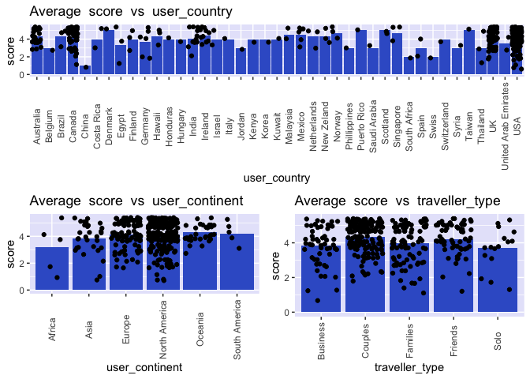

```r
# function to create plot for categorical features


plot_categorical <- function(df, col_name_x, col_name_y = "score"){

  p <-  ggplot(df, aes_string(x = col_name_x, y  = col_name_y))+
    geom_bar(stat = "summary", fun.y = "mean", fill = "royalblue3")+
    geom_jitter()+
    theme(axis.text.x = element_text(angle = 90, vjust = 0.5),panel.background = element_rect(fill =   "lavender"))+
    ggtitle(paste("Average ", col_name_y," vs ", col_name_x))
  p
}

# list to hold plots

cat_plots <- vector('list', length(categorical_features))

cat_plots <- lapply(categorical_features, plot_categorical, df = training_set)

options(repr.plot.height = 10, repr.plot.width = 8)

grid.arrange(cat_plots[[1]], cat_plots[[2]], cat_plots[[3]],  layout_matrix = rbind(c(1,1),c(2,3)))
```

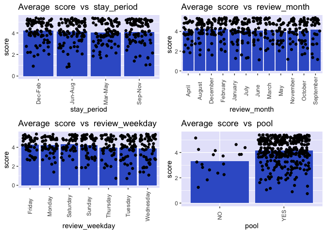

```r
grid.arrange(cat_plots[[4]], cat_plots[[5]], cat_plots[[6]], cat_plots[[7]])
```

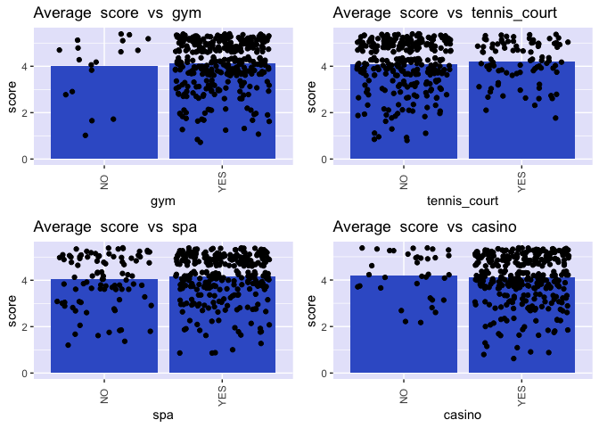

```r
grid.arrange(cat_plots[[8]], cat_plots[[9]], cat_plots[[10]], cat_plots[[11]])
```

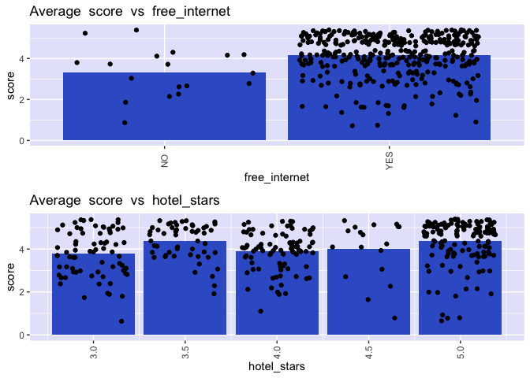

```r
grid.arrange(cat_plots[[12]], cat_plots[[13]])
```

Performing some wrangling based on the observations to further polish the dataset.

```r
# removing user_countries column

training_set <- training_set[, -c(1)]

# Re-categorizing review months as quarters of a year rather than individual months.
training_set$review_month <- factor(training_set$review_month)

levels(training_set$review_month) = list("Q1" = c("January", "February", "March"),
                                       "Q2" = c("April", "May", "June"),
                                       "Q3" = c("July", "August", "September"),
                                       "Q4" = c("October", "November", "December"))


# Re-categorizing review_weekday as weekends and weekdays rather than days of the week.
# including Friday in weekend category

training_set$review_weekday <- factor(training_set$review_weekday)
levels(training_set$review_weekday) <- list("Weekday" = c("Monday", "Tuesday", "Wednesday", "Thursday"),
                                            "Weekend" = c("Friday","Saturday", "Sunday"))


# renaming these columns

colnames(training_set)[4:5] <- c("review_quarter", "review_day")

# updating categorical feature vector
categorical_features <- categorical_features[-1]
categorical_features[4:5] <- c("review_quarter", "review_day")

# updating user_specific feature vector
user_specific_features <- user_specific_features[-1]
user_specific_features[4:5] <- c("review_quarter", "review_day")
```

Visualizing updated relationship plots for these variables.

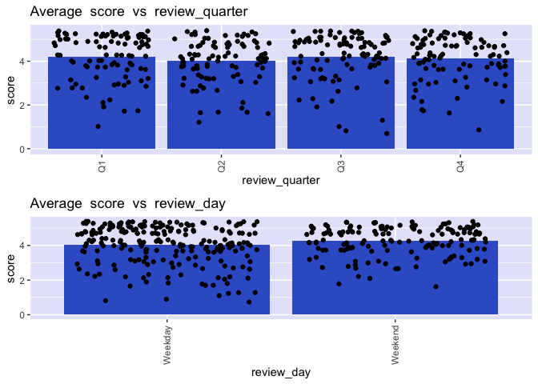

```r
# list to hold plots

cat_plots <- vector('list', length(categorical_features))

cat_plots <- lapply(categorical_features, plot_categorical, df = training_set)

grid.arrange(cat_plots[[4]], cat_plots[[5]])
```

### Inspecting relationship between hotel scores and numeric features

Having explored relationship between categorical features and target score. Lets see how continous features affect hotel scores.

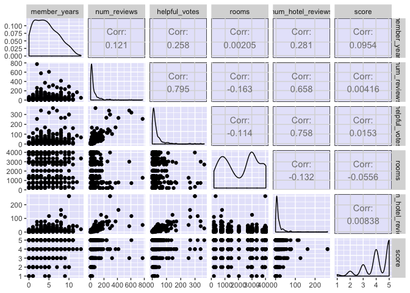

```r
ggpairs(training_set, c(numerical_features, "score"))+
   theme(panel.background = element_rect(fill =   "lavender"))
```

Clearly based on the plot above we can see that there is not much correlation between numeric features and the scores. This theoretically makes sense as number of reviews from users, number of hotel reviews etc. should have minimal impact on scores. But it might not be a good idea to remove these features at this stage. We can first create baseline model and do further feature engineering.

## Summary of EDA

- Based on the exploratory data analysis of different features, we see that some features like having a pool, free internet etc. signiciantly improves hotel scores while other features like most of numeric features, review days etc. do not seem to have any significant impact on average hotel scores.
- Two of the features/columns - user_country and hotel_names were removed as based on EDA, those either do not contribute to the average hotel score or their contribution cannot be generalized. There are other features which may be removed but we will first create a baseline model and compare relative feature importances with EDA analysis and then do feature reduction.

## Next Steps

The planned next course of action is as follows.

- Do pre-processing of dataset before developing linear regression(and/or other generalized linear regression models)
- Develop models
- Feature engineering based on results
- Improve models(iterative)
- Report final results